# MAST30027: Simulation and Rejection Sampling

Week 9 - Solutions

**Objectives of the Tutorial/Lab** By the end of this tutorial, you should be able to:

- Simulate marginal distributions under a Bayesian framework.
- Simulate random variables using rejection sampling algorithm.
- Verify that the simulated samples are consistent with the theoretical distribution.

## Question 1

Suppose that $X \sim \text{Bin}(n, \theta)$ and $\theta \sim \text{Beta}(a,b)$. That is, $X|\theta$ has the pmf

$$p_{X|\theta}(x) = {n \choose x} \theta^x (1-\theta)^{n-x}$$

and $\theta$ has pdf

$$f_\theta(x) = \beta(a,b)^{-1} x^{a-1}(1-x)^{b-1}.$$

The marginal distribution of $X$ is given by

$$p_X(x) = \int_0^1 p_{X|\theta}(x) f_\theta(\theta) d\theta.$$

$X$ is said to have a beta-binomial distribution. It is possible, but not easy, to work out $p_X$ for a beta-binomial. However, it is easy to estimate it using simulation.

Generate a sample of size 1000,000 from a beta-binomial with $n = 10$, $a = 2$ and $b = 3$. Use it to estimate the pmf of $X$.

**💡 Solution**

```r
set.seed(300279)
N <- 1e6
tha <- rbeta(N, 2, 3)
X <- rbinom(N, 10, tha)
(p_X <- table(X)/N)
```

```
X
       0        1        2        3        4        5        6        7
0.066230 0.109620 0.135315 0.144036 0.139627 0.125845 0.104476 0.079741
       8        9       10
0.054031 0.029951 0.011128
```

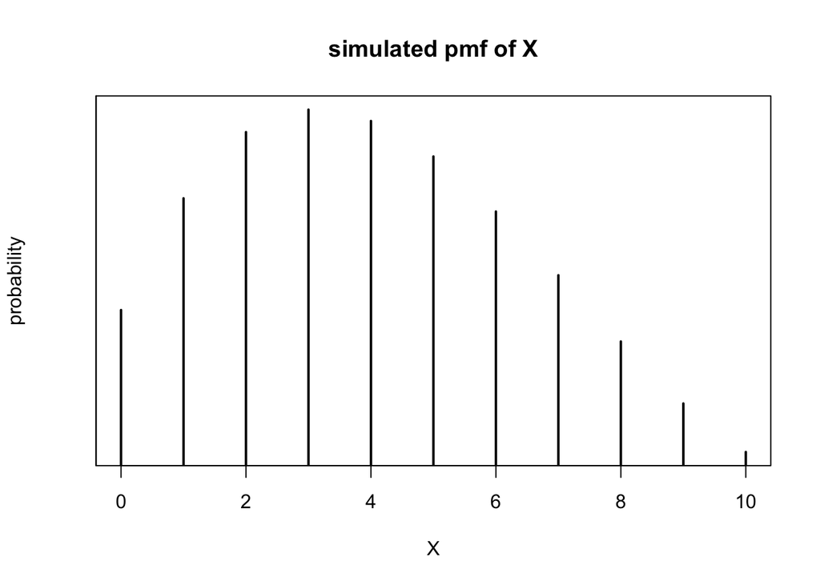

```r
plot(sort(unique(X)), p_X, type='h',xlab="X",
 ylab="probability", lwd=2,main="simulated pmf of X")
```

**📈 Plotting it using ggplot2**

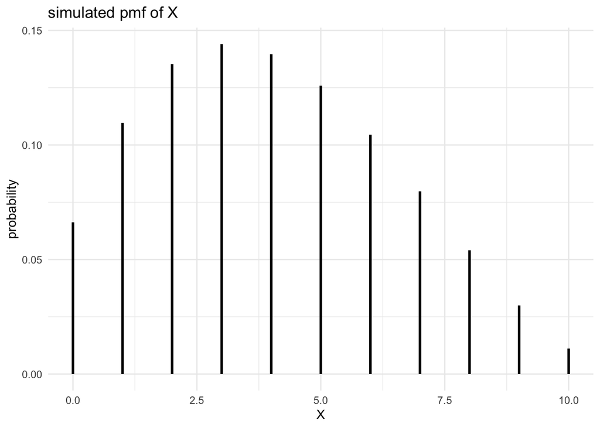

```r
library(ggplot2)
pmf_df <- data.frame(X=as.numeric(names(p_X)), probability=as.numeric(p_X))
ggplot(pmf_df, aes(X, probability)) +
  geom_segment(aes(xend=X, y=0, yend=probability), linewidth=1) +
  labs(title="simulated pmf of X") +
  theme_minimal()
```

## Question 2

Suppose that Z follows a truncated exponential distribution, which has the pdf $p(z)=\frac{e^{-z}}{1-e^{-1}}$, $0<z<1$. Its theoretical mean and variance are known to be $E(Z) = 0.418$ and $\text{Var}(Z) = 0.079$.

Construct an rejection sampling algorithm to generate a sample of observations from the truncated exponential distribution.

**💡 Solution**

When $0<z<1$, $p(z)<(1-e^{-1})^{-1} < \infty$, so we can use a rectangular envelope to contain the density. We get the following rejection algorithm:

1. Generate $X \sim (0,1)$.
2. Generate $Y \sim (0,1/(1-e^{-1}))$ independently.
3. If $Y \leq p(X)$ return $X$; otherwise go to Step $1$.

Write an R program to implement the algorithm in (a) and use it to generate a sample of $10000$ observations. Plot a histogram of the sample. Calculate the sample mean and variance, and compare them with the theoretical mean and variance.

**💡 Solution**

We implement the algorithm in (a) and generate a sample of 10000 observations. We compute the sample mean and variance and compare them to the theoretical values. We also plot a histogram of the sample.

```r
trunc_exp <- function(){
  # generate a truncated exponetial random variable using the rejection algorithm
  x <- runif(1)
  y <- runif(1, 0, 1/(1 - exp(-1)))
  while (y > exp(-x)/(1 - exp(-1))){
    x <- runif(1)
    y <- runif(1, 0, 1/(1 - exp(-1)))
  }
  return(x)
}

# generate a sample of size n
set.seed(30027)
n <- 10000
z <- rep(0, n)
for (i in 1:n) z[i] <- trunc_exp()
# sample mean and variance
mean(z)
```

```
[1] 0.4159879
```

```r
var(z)
```

```
[1] 0.07836399
```

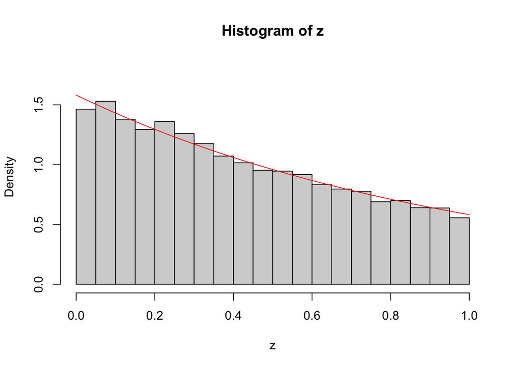

```r
# histogram with density on top
hist(z, freq=FALSE, ylim=c(0,1.8))
curve(exp(-x)/(1 - exp(-1)), 0, 1, add=TRUE, col="red")
```

**📈 Plotting it using ggplot2**

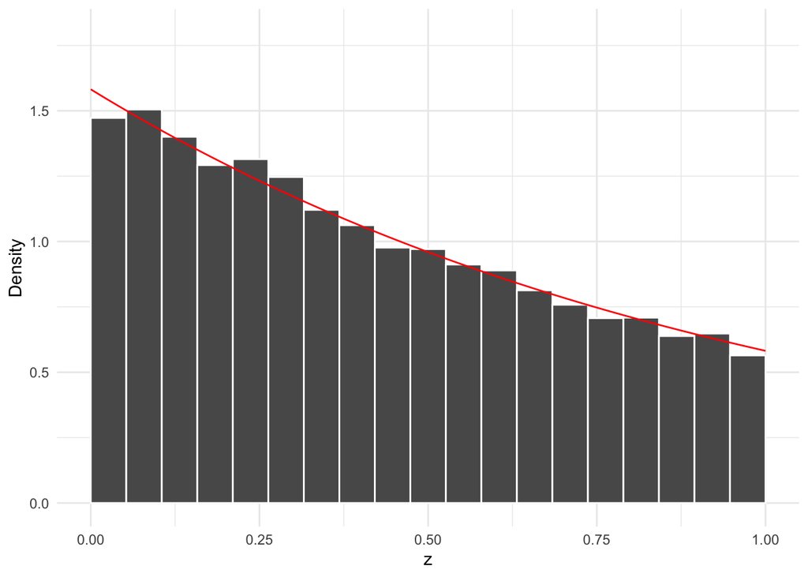

```r
library(ggplot2)
ggplot(data.frame(z=z), aes(z)) +
  geom_histogram(aes(y=after_stat(density)), breaks = seq(0, 1, length.out=20), colour="white") +
  stat_function(fun=function(x) exp(-x)/(1-exp(-1)), xlim=c(0,1), colour="red") +
  coord_cartesian(ylim=c(0,1.8)) + labs(x="z", y="Density") +
  theme_minimal()
```

We can see that the sample mean and variance are similar to the theoretical values.